# Capstone Milestone Report

This report explores the initial exploratory analysis of the English text corpus for the Data Science Capstone course.

## Explore the Data

For this project we are given three files from different sources. See the **Supplemental Information** section for the R code to load the data and create the smaller sample files we use for this analysis. The sample files were created using binomial sampling to select one percent of the full file.

First we load in the data from our sample files and get some line counts.

```r
transform(file.info(list.files("data/sample/", full.names = T))[, "size", drop = FALSE], size = paste0(round(size / 1024 / 1024, 2), "MB"))
```

```
##                              size
## data/sample//blog_samp.txt 1.95MB
## data/sample//news_samp.txt 1.98MB
## data/sample//twit_samp.txt 1.57MB
```

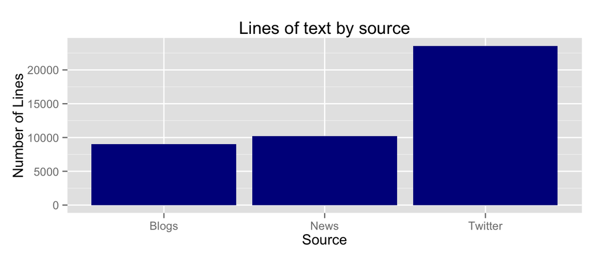

```r
t_samp <- readLines("data/sample/twit_samp.txt")
b_samp <- readLines("data/sample/blog_samp.txt")
n_samp <- readLines("data/sample/news_samp.txt")

lines <- data.frame(lines = c(length(t_samp), length(b_samp), length(n_samp)))
lines$srce <- c("Twitter", "Blogs", "News")
ggplot(lines, aes(x=as.factor(srce), y=lines)) + geom_bar(stat="identity", fill="darkblue") +
    labs(x = "Source", y = "Number of Lines", title = "Lines of text by source")
```

Even though it is the smallest file, we that the twitter sample has substantially more lines of text. This is not that surprising since twitter limits lines of text to 140 characters per tweet while news articles and blogs have no such limit. For our purposes the number of words is more important so we will look at that across the three files.

### Words

Frist we will clean up the data a little, such as getting rid of punctuation and non-letter charactrs as well as stemming, then get word counts. The details of the `cleanText` function are covered in the **Supplemental information** section.

```r
t_words <- cleanText(t_samp)
b_words <- cleanText(b_samp)
n_words <- cleanText(n_samp)

rbind(data.frame(measure = "Number of words",twitter = length(t_words), blogs = length(b_words), news = length(n_words)),
      data.frame(measure = "Number of unique words", twitter = length(unique(t_words)), blogs = length(unique(b_words)), news = length(unique(n_words)))  )
```

```
##                  measure twitter  blogs   news
## 1        Number of words  178893 199723 207917
## 2 Number of unique words   22114  24122  25535
```

We see that even with these small samples there are a large number of unique words in all the files. We also see that eventhough the twitter file as substantially more lines the blogs and news files have approximately 10% more unique words. Since the final product will probably have limited computing resources we will look at the distribution of the words in the different files. We will graph the 500 words in each file that appear the most often. The `createTableOfCounts` function is covered in detail in the **Supplemental information** section.

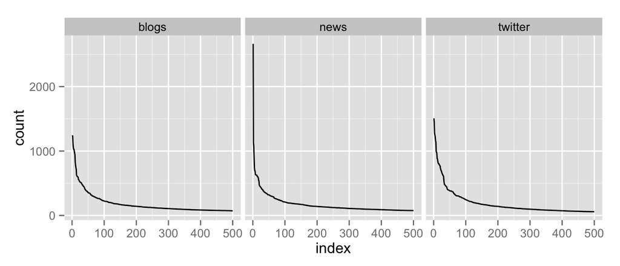

```r
t_df <- createTableOfCounts(t_words, "twitter")
b_df <- createTableOfCounts(b_words, "blogs")
n_df <- createTableOfCounts(n_words, "news")

df <- rbind(t_df[1:500], b_df[1:500], n_df[1:500])
ggplot(df, aes(x=index, y=count)) + geom_line() + facet_grid(. ~ src)
```

We see that in our samples some words are used far more often than most of the other words. Since this is the case we will see how many words we would need to have to cover 50% of all words and 90% of all words.

```r
coverage_df <- coverageNums(t_df, .5) %>% rbind(coverageNums(b_df, .5)) %>% rbind(coverageNums(n_df, .5)) %>%
    rbind(coverageNums(t_df, .9)) %>% rbind(coverageNums(b_df, .9)) %>%rbind(coverageNums(n_df, .9))
coverage_df
```

```
##    Source Coverage Words_Needed Percent_of_Unique_Words
## 1 twitter      50%          406                      2%
## 2   blogs      50%          632                      3%
## 3    news      50%          765                      3%
## 4 twitter      90%         6881                     31%
## 5   blogs      90%         8073                     33%
## 6    news      90%         8805                     34%
```

We see that with only about 3% of the most common words we can cover 50% of all word occurences, and with about 34% we can cover 90% of all word occurences. We can use this information if we find out in testing the final application that we are not meeting our performance targets and cannot use 100% of all the words in our final model.

Top 10 most common words for tweets, blogs, and news articles.

```r
data.frame(twitter = t_df$word[1:10], blogs = b_df$word[1:10], news = n_df$word[1:10])
```

```
##    twitter blogs  news
## 1     just    on  said
## 2      get  will  year
## 3     like  like  will
## 4       go   can    on
## 5     love  time   new
## 6        u    it    it
## 7    thank     t   can
## 8     good  just  like
## 9     will   get state
## 10     can     i    go
```

We can see from this small list that the most common words appear to differ some between tweets, blogs, and news articles. This indicates that we may want to use different dictionaries for depending on the what context we are trying to predict the next word.

### N-grams

For predicion purposes we would like to use bigrams (composed of two words) and trigrams (composed of 3 words) since this allows the use of more information in predicting the next word compared to using on ony a single word. We will create the bigrams after cleaning the words. In this case we will pass sentences to the n-gram creating function (from the RWeka package) instead of a list of words otherwise, we will get word combinations that cross sentences and tweets.

First, clean the lines of text.

```r
suppressMessages(library(RWeka))

t_cln <- sapply(t_samp, cleanText, TRUE)
b_cln <- sapply(b_samp, cleanText, TRUE)
n_cln <- sapply(n_samp, cleanText, TRUE)
```

Create the bigrams.

```r
t_bi <- NGramTokenizer(t_cln, control=Weka_control(min=2, max=2, dilimeters = " ")) %>% createTableOfCounts("twitter")
b_bi <- NGramTokenizer(b_cln, control=Weka_control(min=2, max=2, dilimeters = " ")) %>% createTableOfCounts("blogs")
n_bi <- NGramTokenizer(n_cln, control=Weka_control(min=2, max=2, dilimeters = " ")) %>% createTableOfCounts("news")
```

Create the trigrams.

```r
t_tri <- NGramTokenizer(t_cln, control=Weka_control(min=3, max=3, dilimeters = " ")) %>% createTableOfCounts("twitter")
b_tri <- NGramTokenizer(b_cln, control=Weka_control(min=3, max=3, dilimeters = " ")) %>% createTableOfCounts("blogs")
n_tri <- NGramTokenizer(n_cln, control=Weka_control(min=3, max=3, dilimeters = " ")) %>% createTableOfCounts("news")
```

Now we look at the numbers of unique bigrams and trigrams along with their distributions for the three files.

```r
rbind(data.frame(measure = "Number unique bigrams",twitter = dim(t_bi)[1], blogs = dim(b_bi)[1], news = dim(n_bi)[1]),
      data.frame(measure = "Number unique trigrams",twitter = dim(t_tri)[1], blogs = dim(b_tri)[1], news = dim(n_tri)[1])  )
```

```
##                  measure twitter  blogs   news
## 1  Number unique bigrams  127449 164460 170311
## 2 Number unique trigrams  130696 179986 185238
```

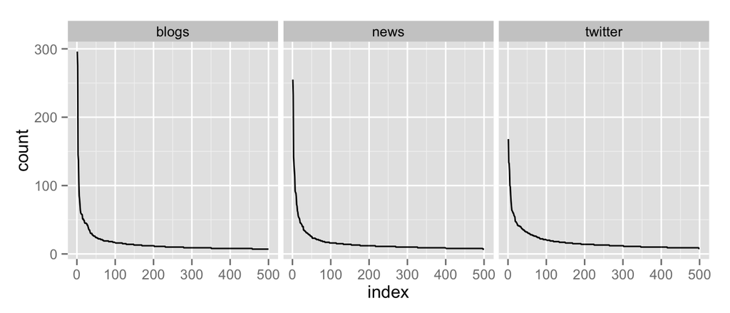

```r
bi_df <- rbind(t_bi[1:500], b_bi[1:500], n_bi[1:500])
ggplot(bi_df, aes(x=index, y=count)) + geom_line() + facet_grid(. ~ src)
```

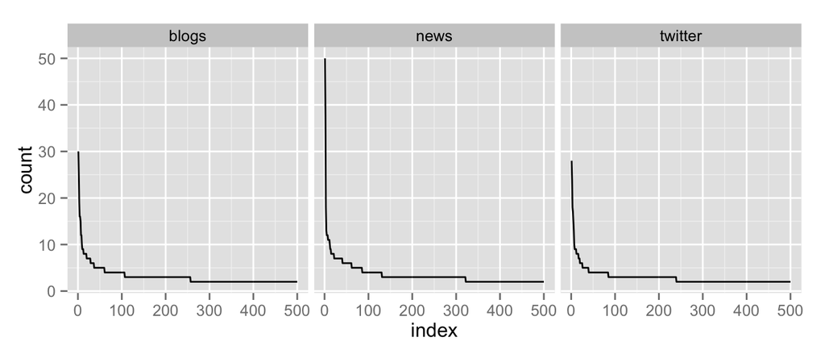

```r
tri_df <- rbind(t_tri[1:500], b_tri[1:500], n_tri[1:500])
ggplot(tri_df, aes(x=index, y=count)) + geom_line() + facet_grid(. ~ src)
```

Like single words, bigrams and trigrams have a few instances that are much more common. However, as we move from single words to bigrams to trigrams we see that the counts for the most common instances in the text drop. This may impact our ability to use a small subset of bigrams and trigrams in our dictionary. We will see if we can achieve similar coverage with bigrams and trigrams as we did with single words.

```r
coverage_bi <- coverageNums(t_bi, .5) %>% rbind(coverageNums(b_bi, .5)) %>% rbind(coverageNums(n_bi, .5)) %>%
    rbind(coverageNums(t_bi, .9)) %>% rbind(coverageNums(b_bi, .9)) %>%rbind(coverageNums(n_bi, .9))

coverage_bi
```

```
##    Source Coverage Words_Needed Percent_of_Unique_Words
## 1 twitter      50%        49765                     39%
## 2   blogs      50%        69108                     42%
## 3    news      50%        71444                     42%
## 4 twitter      90%       111913                     88%
## 5   blogs      90%       145390                     88%
## 6    news      90%       150538                     88%
```

```r
coverage_tri <- coverageNums(t_tri, .5) %>% rbind(coverageNums(b_tri, .5)) %>% rbind(coverageNums(n_tri, .5)) %>%
    rbind(coverageNums(t_tri, .9)) %>% rbind(coverageNums(b_tri, .9)) %>%rbind(coverageNums(n_tri, .9))

coverage_tri
```

```
##    Source Coverage Words_Needed Percent_of_Unique_Words
## 1 twitter      50%        64521                     49%
## 2   blogs      50%        89002                     49%
## 3    news      50%        91426                     49%
## 4 twitter      90%       117461                     90%
## 5   blogs      90%       161790                     90%
## 6    news      90%       166476                     90%
```

We see that unlike with words, it does not appear a few bigrams or trigrams can provide significant coverage.

## Application Plans

The goal of our application will be to predict the next word given a partial string of words.

1. Create a separate word table for tweets, blogs, and news articles so we use the associated table depending on the application and context.
2. Create bigram and trigram tables for each set of data to use when predicting the next word.
3. Reduce table sizes to work within constraints of Shiny server through a combination of selecting the most common combinations and through methods such as markov chains and word compression.
4. Explore offloading less common combinations to a persistent store that can be accessed from the Shiny application.
5. Train a model at test model.
6. For application, clean entered data before matching with model.
7. If can get the current user application then use the correpsonding twitter, blogs, or news dataset that is best match for the application.

## Supplemental Information

The following packages are used in generating this report

```r
library(tau)
suppressMessages(library(ggplot2))
suppressMessages(library(magrittr))
suppressMessages(library(tm))
suppressMessages(library(SnowballC))
suppressMessages(library(dplyr))
suppressMessages(library(data.table))
suppressMessages(library(RWeka))
```

### Obtaining the data

The data for this project can be obtained from https://d396qusza40orc.cloudfront.net/dsscapstone/dataset/Coursera-SwiftKey.zip

```r
if (!file.exists("data/")) {
    dir.create("data")
}
# If the zip file does not exist then download the file.
if (!file.exists("data/data.zip")) {
    download.file("https://d396qusza40orc.cloudfront.net/dsscapstone/dataset/Coursera-SwiftKey.zip", "data/data.zip", method = "curl")
}
# Check to see if the data/en_US directory exists. If not, extract the files.
if (!file.exists("data/en_US")) {
    unzip("data/data.zip", exdir = "data")
}
```

### Selecting Samples

Due to limited hardware for this stage a binomial sample of 1% of lines from each corpus was selected.

```r
createSampleFile <- function(inFile, outFile, percent = .01) {
  con <- file(inFile,"r")
  fullFile <- readLines(con)
  close(con)

  to_select <- rbinom(n = length(fullFile), size = 1, prob = percent)
  to_select <- to_select > 0
  file_subset <- fullFile[to_select]

  # Write out the sample file can free space
  outCon <- file(outFile, "w")
  writeLines(file_subset, con = outCon)
  close(outCon)
}

set.seed(10)
createSampleFile("data/en_US/en_US.twitter.txt", "data/sample/twit_samp.txt")
createSampleFile("data/en_US/en_US.blogs.txt", "data/sample/blog_samp.txt")
createSampleFile("data/en_US/en_US.news.txt", "data/sample/news_samp.txt")
gc()
```

### Cleaning the data

For this report a `cleanText` function was created to clean the data for further processing. The function converts the text to lower case, removes punctuation, non-alpha characters (which handles unicode), removes stopwords (extremely common words), and stems the words (removes endings such as *ing*)

```r
cleanText <- function(data, split=FALSE) {
    data <- unlist(strsplit(data, split=" "))    %>%
        tolower                                  %>%
        remove_stopwords(stopwords())            %>%
        function (x) gsub("[[:punct:]]", " ", x) %>%
        function (x) gsub("[^a-z]", " ", x)      %>%
        function (x) gsub("[ ]{2}", " ", x)      %>%
        function (x) x[ x != " "]                %>%
        wordStem
    if (split) {
        data <- paste(data, collapse = " ")
    } else {
        data <- unlist(strsplit(data, split = " "))
    }
    data
}
```

### Gathering counts

To gather counts the `createTableOfCounts` function was used which counted the number occurences of each unique instance and ordered them in decending frequency order.

```r
createTableOfCounts <- function(x, id="default") {
    wrds <- table(x)
    df <- data.table(word = names(wrds), count = as.numeric(wrds)) %>%
        mutate(src = id) %>%
        arrange(desc(count)) %>%
        mutate(index = seq_len(length(count)), cum_count = cumsum(count))
}
```